# Analysis of Simulation Distribution

Brady Chiu

May 2, 2016

# 1 Intro

This project investigates the exponential distribution in R and compare it with the Central Limit Theorem. We use the rexp(n, lambda) to generate our distributions, and observe 1000 simulations of 40 samples each with a lambda = 0.2.

We aim to show the following:

1. Show the sample mean and compare it to the theoretical mean of the distribution
2. Show how variable the sample is (via variance) and compare it to the theoretical variance of the distribution
3. Show that the distribution is approximately normal

# 2 Simulation

- We define our simulation paramters

```r
exponentials<-40
lambda<-0.2
simulation_count<-1000
```

- We run our simulation by inputting the parameters above into the rexp(n,lambda) function

```r
simulation_result<-simulator(exponentials,lambda,simulation_count)
head(simulation_result,10)
```

```
##        mean
## 1  3.383281
## 2  6.246429
## 3  4.308285
## 4  4.914561
## 5  5.190411
## 6  5.820374
## 7  5.375244
## 8  5.005151
## 9  4.195586
## 10 4.707139
```

# 3 Mean

- We calculate the theoretical and sample means

```r
theoretical_mean<-1/lambda
sample_mean<-mean(simulation_result$mean)
```

```
## [1] "Theoretical Mean: 5"
```

```
## [1] "Sample Mean: 5.05599525594939"
```

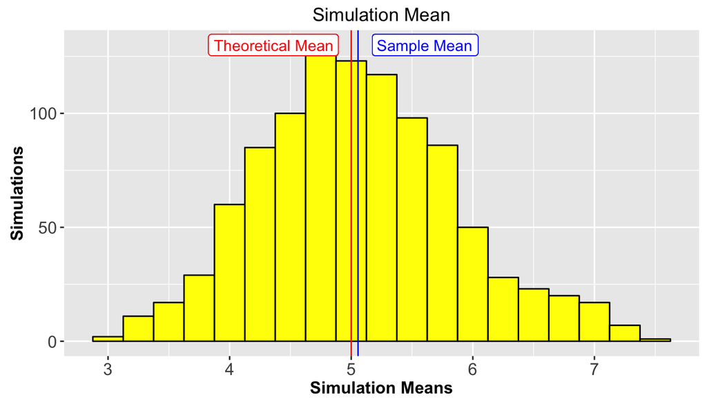

- Our theoretical and sample means are almost identical

# 4 Variance

- We calculate the theoretical and sample variances

```r
theoretical_variance<-(1/lambda)^2/exponentials
sample_variance<-var(simulation_result$mean)
```

```
## [1] "Theoretical Variance: 0.625"
```

```
## [1] "Sample Variance: 0.654370303983734"
```

- Our theoretical and sample variances are almost identical